# Exploration and Analysis of Student Exam Performance

## Arjun Patel, Navreet Bajwa, Yash Upadhyay

### Introduction

Exam performance for students in high school is crucial to their future success. For our final project, we chose a dataset from Kaggle titled "Student Alcohol Consumption" which contains data gathered from a survey of students from two schools in Portugal about their weekday and weekend alcohol consumption as well as many other general attributes such as highest level of education achieved by their mother and father, how many extracurricular activities they're involved in, weekly study time, whether they want to pursue higher education, and many more.

The objective of our project was to try to predict exam performance using variables that seemed most intuitively relevant like study time, whether they take extra paid classes or not, whether or not they want to pursue higher education, and number of absences. We also investigated some of the more interesting and less intuitive variables like alcohol consumption, whether or not they're in a romantic relationship

### Data Collection & Processing

We'll start by importing some necessary libraries and modules

```python
#importing libaries
import pandas as pd
import matplotlib.pyplot as plt
import numpy as np
import scipy
import seaborn as sb
import statsmodels.formula.api as sm
import statsmodels.api as smf
from statsmodels.stats.weightstats import ztest
```

Here is a link to our dataset: https://www.kaggle.com/uciml/student-alcohol-consumption/.  
Our data collection process consists of simply loading in the csv file "student-mat.csv" in the dataset which contains information on students in a math course. However, we still have some tidying to do as part of our data processing. After manually inspecting the columns contained in the csv file, we decided on which data we wanted to focus on for our analysis and which data we would discard. The column variables we decided to keep are:

- student's sex (binary: 'F' - female or 'M' - male)
- age - student's age (numeric: from 15 to 22)
- Pstatus - parent's cohabitation status (binary: 'T' - living together or 'A' - apart)
- Medu - mother's education (numeric: 0 - none, 1 - primary education (4th grade), 2 – 5th to 9th grade, 3 – secondary education or 4 – higher education)
- Fedu - father's education (numeric: 0 - none, 1 - primary education (4th grade), 2 – 5th to 9th grade, 3 – secondary education or 4 – higher education)
- studytime - weekly study time (numeric: 1 - <2 hours, 2 - 2 to 5 hours, 3 - 5 to 10 hours, or 4 - >10 hours)
- failures - number of past class failures (numeric: n if 1<=n<3, else 4)
- paid - extra paid classes within the course subject (Math or Portuguese) (binary: yes or no)
- activities - extra-curricular activities (binary: yes or no)
- higher - wants to take higher education (binary: yes or no)
- internet - Internet access at home (binary: yes or no)
- romantic - with a romantic relationship (binary: yes or no)
- famrel - quality of family relationships (numeric: from 1 - very bad to 5 - excellent)
- freetime - free time after school (numeric: from 1 - very low to 5 - very high)
- goout - going out with friends (numeric: from 1 - very low to 5 - very high)
- Dalc - workday alcohol consumption (numeric: from 1 - very low to 5 - very high)
- Walc - weekend alcohol consumption (numeric: from 1 - very low to 5 - very high)
- absences - number of school absences (numeric: from 0 to 93)
- G1 - first period grade (numeric: from 0 to 20)
- G2 - second period grade (numeric: from 0 to 20)
- G3 - final grade (numeric: from 0 to 20, output target)  
  We dropped the rest of the columns and added three columns. One with their average grade from G1, G2 and G3, one with their average alcohol consumption using workday and weekend alcohol consumption, and one with their parent's education aggregated as an average of their mother and father's education levels.  
  We also added buckets for absences rather than keeping the numeric value for absences

```python
tidy_data = pd.read_csv("student-mat.csv")
tidy_data = tidy_data.drop(['school','address','famsize','Mjob','Fjob','reason','guardian',
                'traveltime','schoolsup','famsup','nursery','health'], axis=1)
for i,row in tidy_data.iterrows():
    tidy_data.at[i,'Avg_Alc_Consumption'] = float((row['Dalc'] + row['Walc'])/2)
    tidy_data.at[i,'Parent_Education'] = float((row['Medu'] + row['Fedu'])/2)
    tidy_data.at[i,'Average_Score'] = float((row['G1']+row['G2']+row['G3'])/3)

tidy_data = tidy_data.drop(['Dalc','Walc','Medu', 'Fedu', 'G1', 'G2', 'G3'], axis=1)

absencebins=[0,5,10,20,25,30]
labels=[0,1,2,3,4]
tidy_data['absences'] = pd.cut(tidy_data['absences'], bins=absencebins, labels=labels, include_lowest=True)
tidy_data['absences'] = tidy_data['absences'].cat.codes
tidy_data['absences'] = tidy_data['absences'].astype('int64', errors='ignore')
tidy_data.head()
```

|  | sex | age | Pstatus | studytime | failures | paid | activities | higher | internet | romantic | famrel | freetime | goout | absences | Avg_Alc_Consumption | Parent_Education | Average_Score |
| --- | --- | --- | --- | --- | --- | --- | --- | --- | --- | --- | --- | --- | --- | --- | --- | --- | --- |
| 0 | F | 18 | A | 2 | 0 | no | no | yes | no | no | 4 | 3 | 4 | 1 | 1.0 | 4.0 | 5.666667 |
| 1 | F | 17 | T | 2 | 0 | no | no | yes | yes | no | 5 | 3 | 3 | 0 | 1.0 | 1.0 | 5.333333 |
| 2 | F | 15 | T | 2 | 3 | yes | no | yes | yes | no | 4 | 3 | 2 | 1 | 2.5 | 1.0 | 8.333333 |
| 3 | F | 15 | T | 3 | 0 | yes | yes | yes | yes | yes | 3 | 2 | 2 | 0 | 1.0 | 3.0 | 14.666667 |
| 4 | F | 16 | T | 2 | 0 | yes | no | yes | no | no | 4 | 3 | 2 | 0 | 1.5 | 3.0 | 8.666667 |

We also went ahead and converted the binary string variables to numerical values. For sex, we'll change F to 1 and M to 0 and for the rest, we'll make Yes 1 and No 0.

```python
tidy_data.sex.replace(('F', 'M'), (1,0), inplace=True)
tidy_data.paid.replace(('yes', 'no'), (1,0), inplace=True)
tidy_data.activities.replace(('yes', 'no'), (1,0), inplace=True)
tidy_data.higher.replace(('yes', 'no'), (1,0), inplace=True)
tidy_data.internet.replace(('yes', 'no'), (1,0), inplace=True)
tidy_data.romantic.replace(('yes', 'no'), (1,0), inplace=True)
tidy_data.Pstatus.replace(('T', 'A'), (1,0), inplace=True)
tidy_data.head()
```

|  | sex | age | Pstatus | studytime | failures | paid | activities | higher | internet | romantic | famrel | freetime | goout | absences | Avg_Alc_Consumption | Parent_Education | Average_Score |
| --- | --- | --- | --- | --- | --- | --- | --- | --- | --- | --- | --- | --- | --- | --- | --- | --- | --- |
| 0 | 1 | 18 | 0 | 2 | 0 | 0 | 0 | 1 | 0 | 0 | 4 | 3 | 4 | 1 | 1.0 | 4.0 | 5.666667 |
| 1 | 1 | 17 | 1 | 2 | 0 | 0 | 0 | 1 | 1 | 0 | 5 | 3 | 3 | 0 | 1.0 | 1.0 | 5.333333 |
| 2 | 1 | 15 | 1 | 2 | 3 | 1 | 0 | 1 | 1 | 0 | 4 | 3 | 2 | 1 | 2.5 | 1.0 | 8.333333 |
| 3 | 1 | 15 | 1 | 3 | 0 | 1 | 1 | 1 | 1 | 1 | 3 | 2 | 2 | 0 | 1.0 | 3.0 | 14.666667 |
| 4 | 1 | 16 | 1 | 2 | 0 | 1 | 0 | 1 | 0 | 0 | 4 | 3 | 2 | 0 | 1.5 | 3.0 | 8.666667 |

We then created subset dataframes for different categories using the relevant columns.

```python
#Dataframe that consists of all the after school activities that a student participates in
after_school_activities = tidy_data.copy()
after_school_activities = after_school_activities.drop(['higher','absences','Parent_Education','sex',
                            'age','Pstatus','failures','internet','famrel','Avg_Alc_Consumption'],axis=1)
after_school_activities.head()
```

|  | studytime | paid | activities | romantic | freetime | goout | Average_Score |
| --- | --- | --- | --- | --- | --- | --- | --- |
| 0 | 2 | 0 | 0 | 0 | 3 | 4 | 5.666667 |
| 1 | 2 | 0 | 0 | 0 | 3 | 3 | 5.333333 |
| 2 | 2 | 1 | 0 | 0 | 3 | 2 | 8.333333 |
| 3 | 3 | 1 | 1 | 1 | 2 | 2 | 14.666667 |
| 4 | 2 | 1 | 0 | 0 | 3 | 2 | 8.666667 |

```python
# Dataframe that contains information about the students family
family_data = tidy_data.copy()
family_data = family_data.drop(['higher','absences','Parent_Education','sex','age','studytime','failures','paid','activities','internet','romantic','goout'
                               ,'freetime','Avg_Alc_Consumption'],axis=1)
family_data.head()
```

|  | Pstatus | famrel | Average_Score |
| --- | --- | --- | --- |
| 0 | 0 | 4 | 5.666667 |
| 1 | 1 | 5 | 5.333333 |
| 2 | 1 | 4 | 8.333333 |
| 3 | 1 | 3 | 14.666667 |
| 4 | 1 | 4 | 8.666667 |

### Exploratory Data Analysis (EDA)/Data Visualization

The next step in the data analysis process is to perform some EDA to discover any relationships among the data we're interested in.

In order to get a feel for our data, we explored the linear correlation between all of our relevant variables. The correlation coefficient is a numerical value between -1 and 1, inclusive. It tells us the strength of the relationship between two variables, specifically a linear relationship in our case. Ideally, we want our correlation coefficient to be either greater than 0.5 or less than -0.5.  
If you are interested in learning the details of correlation like how it's calculated and it's significance, please check out https://www.datascience.com/learn-data-science/fundamentals/introduction-to-correlation-python-data-science

We started by calculating the linear correlations using the built-in corr() function from our tidy_data dataframe. We then created a heatmap visualization of the correlation matrix using the Seaborn library. Each cell in the matrix contains the correlation coefficient between the corresponding row and column variable from our dataset.

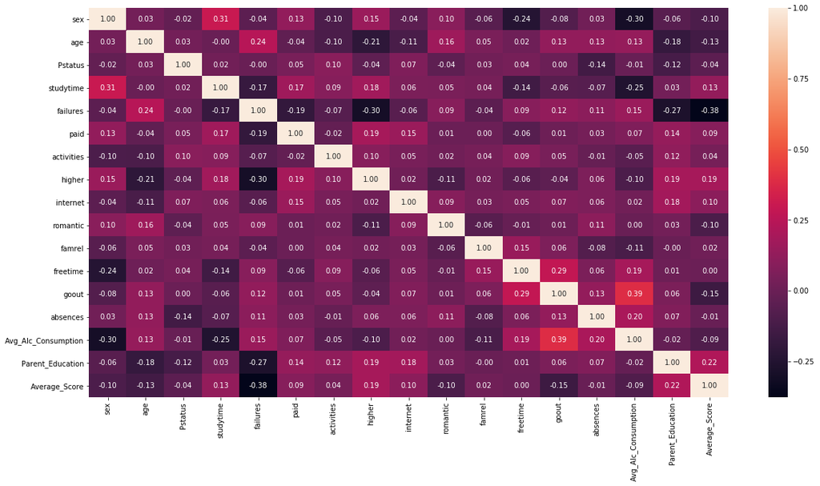

```python
plt.figure(figsize=(20,10))
sb.heatmap(tidy_data.corr(), annot=True,fmt=".2f",cbar=True)
plt.show()
```

```python
male_avg = 0
female_avg = 0
male_count = 0
female_count = 0

for i,person in tidy_data.iterrows():
    if person['sex'] == 0:
        male_avg+=person['Average_Score']
        male_count+=1
    elif person['sex'] == 1:
        female_avg+=person['Average_Score']
        female_count+=1

male_avg/=male_count
female_avg/=female_count

# Calculating the average scores for both genders
print("Male Avg Scores: " + str(male_avg))
print("Female Avg Scores: " + str(female_avg))
```

```
Male Avg Scores: 11.073083779
Female Avg Scores: 10.3253205128
```

The average score for males is higher than for females but we can't say for sure if this is a significant difference without a formal hypothesis test. We then conduct a two-sample t test to see if there is a significant difference in average exam score between males and females for this population. Note that for this and the following categorical variables, we assume the variances are unequal for the two groups.

```python
males = tidy_data.loc[tidy_data['sex'] == 0]
females = tidy_data.loc[tidy_data['sex'] == 1]
males = males.drop(['sex','age','Pstatus','failures','internet','famrel','Avg_Alc_Consumption',
    'studytime', 'paid', 'activities', 'romantic', 'freetime', 'goout', 'higher', 'absences', 'Parent_Education'],axis=1)
females = females.drop(['sex','age','Pstatus','failures','internet','famrel','Avg_Alc_Consumption',
    'studytime', 'paid', 'activities', 'romantic', 'freetime', 'goout', 'higher', 'absences', 'Parent_Education'],axis=1)
t,p = scipy.stats.ttest_ind(males, females, axis=0,equal_var=False) #assuming unequal variances between the groups
print("t-test p value is", float(p))
```

```
t-test p value is 0.045040833230012865
```

Our p-value of 0.045 < $ \alpha $ = 0.10 so we reject the null hypothesis that there is no significant difference in average score between males and females. Thus, we conclude that gender is a significant factor for predicting average score. When we later do our linear regression to try to predict average score, we will include gender as an independent variable.

The next categorical variable we tested for significance was parent cohabitation status - 1 for parents live together and 0 for parents live separately.

```python
together = tidy_data.loc[tidy_data['Pstatus'] == 1]
apart = tidy_data.loc[tidy_data['Pstatus'] == 0]
together = together.drop(['sex','age', 'Pstatus','failures','internet','famrel','Avg_Alc_Consumption',
    'studytime', 'paid', 'activities', 'romantic', 'freetime', 'goout', 'higher','absences', 'Parent_Education'],axis=1)
apart = apart.drop(['sex','age', 'Pstatus','failures','internet','famrel','Avg_Alc_Consumption',
    'studytime', 'paid', 'activities', 'romantic', 'freetime', 'goout', 'higher', 'absences', 'Parent_Education'],axis=1)
t,p = scipy.stats.ttest_ind(together, apart, axis=0,equal_var=False)
print("t-test p value is", float(p))
```

```
t-test p value is 0.4055887739147568
```

0.406 > $ \alpha $ = 0.10 so we conclude that the average score is *not* significantly different between students whose parents live together vs whose parents are separated. So we will *not* include parent cohabitation status in our linear regression model.

The next categorical variable we tested for significance was paid - 1(Yes) for students who pay for additional tutoring or 0(No).

```python
tutoring = tidy_data.loc[tidy_data['paid'] == 1]
no_tutoring = tidy_data.loc[tidy_data['paid'] == 0]
tutoring = tutoring.drop(['sex','age', 'Pstatus','failures','internet','famrel','Avg_Alc_Consumption',
    'studytime', 'paid', 'activities', 'romantic', 'freetime', 'goout', 'higher','absences', 'Parent_Education'],axis=1)
no_tutoring = no_tutoring.drop(['sex','age', 'Pstatus','failures','internet','famrel','Avg_Alc_Consumption',
    'studytime', 'paid', 'activities', 'romantic', 'freetime', 'goout', 'higher','absences', 'Parent_Education'],axis=1)
t,p = scipy.stats.ttest_ind(tutoring, no_tutoring, axis=0,equal_var=False)
print("t-test p value is", float(p))
```

```
t-test p value is 0.06921513216047903
```

0.069 < $ \alpha $ = 0.10, we conclude that the average score is significantly different between students who pay for extra tutoring and those who don't. So we will include paid in our linear regression model.

The next categorical variable we tested for significance was activities - Yes for students who are involved in extracurricular activities or No.

```python
activities = tidy_data.loc[tidy_data['activities'] == 1]
no_activities = tidy_data.loc[tidy_data['activities'] == 0]
activities = activities.drop(['sex','age', 'Pstatus','failures','internet','famrel','Avg_Alc_Consumption',
    'studytime', 'paid', 'activities', 'romantic', 'freetime', 'goout', 'higher','absences', 'Parent_Education'],axis=1)
no_activities = no_activities.drop(['sex','age', 'Pstatus','failures','internet','famrel','Avg_Alc_Consumption',
    'studytime', 'paid', 'activities', 'romantic', 'freetime', 'goout', 'higher','absences', 'Parent_Education'],axis=1)
t,p = scipy.stats.ttest_ind(activities, no_activities, axis=0,equal_var=False)
print("t-test p value is", float(p))
```

```
t-test p value is 0.41816414273867775
```

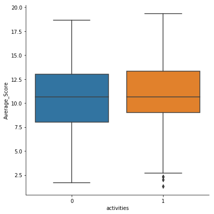

```python
sb.catplot(x="activities", y="Average_Score",data=tidy_data, kind="box", height = 6)
```

Based on this boxplot, it looks like the mean Average_Score is not much different for students in extracurricular activities but their distribution is more skewed towards higher scores as it has a higher minimum, higher quartile 1 and 3 values, and higher minimum. So we will keep activities as a variable for our linear regression later even though we didn't get a significant p-value for it.

The next categorical variable we tested for significance was higher - Yes for students who are interested in higher education or No.

```python
higher = tidy_data.loc[tidy_data['higher'] == 1]
no_higher = tidy_data.loc[tidy_data['higher'] == 0]
higher = higher.drop(['sex','age', 'Pstatus','failures','internet','famrel','Avg_Alc_Consumption',
    'studytime', 'paid', 'activities', 'romantic', 'freetime', 'goout', 'higher','absences', 'Parent_Education'],axis=1)
no_higher = no_higher.drop(['sex','age', 'Pstatus','failures','internet','famrel','Avg_Alc_Consumption',
    'studytime', 'paid', 'activities', 'romantic', 'freetime', 'goout', 'higher','absences', 'Parent_Education'],axis=1)
t,p = scipy.stats.ttest_ind(higher, no_higher, axis=0,equal_var=False)
print("t-test p value is", float(p))
```

```
t-test p value is 0.000561803657156937
```

0.00056 < $ \alpha $ = 0.10, we conclude that the average score is significantly different between students who are interested in higher education and those who are not.  
Wow! Our p value is very low which is an ideal result. Let's look a bit deeper into the higher variable to see if there is any information that might help us understand if this low p value is meaningful.

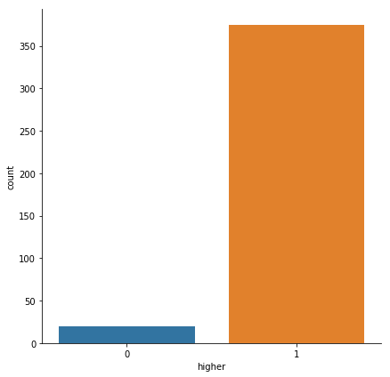

```python
sb.catplot(x="higher", data=tidy_data, kind="count", height = 6)
```

Very few students in the dataset said they were not interested in higher education so there might not be enough data to meaningfully analyze this. Nevertheless, we will keep higher as a variable for our linear regression.

The next categorical variable we tested for significance was internet - Yes for students who have internet access at home or No.

```python
internet = tidy_data.loc[tidy_data['internet'] == 1]
no_internet = tidy_data.loc[tidy_data['internet'] == 0]
internet = internet.drop(['sex','age', 'Pstatus','failures','internet','famrel','Avg_Alc_Consumption',
    'studytime', 'paid', 'activities', 'romantic', 'freetime', 'goout', 'higher','absences', 'Parent_Education'],axis=1)
no_internet = no_internet.drop(['sex','age', 'Pstatus','failures','internet','famrel','Avg_Alc_Consumption',
    'studytime', 'paid', 'activities', 'romantic', 'freetime', 'goout', 'higher','absences', 'Parent_Education'],axis=1)
t,p = scipy.stats.ttest_ind(internet, no_internet, axis=0,equal_var=False)
print("t-test p value is", float(p))
```

```
t-test p value is 0.03811743647022728
```

0.038 < $ \alpha $ = 0.10, we conclude that the average score is significantly different between students who have internet access at home and those who don't. So we will include internet in our linear regression model.

The next categorical variable we tested for significance was romantic - Yes for students who are in a romantic relationship or No.

```python
romantic = tidy_data.loc[tidy_data['romantic'] == 1]
no_romantic = tidy_data.loc[tidy_data['romantic'] == 0]
romantic = romantic.drop(['sex','age', 'Pstatus','failures','internet','famrel','Avg_Alc_Consumption',
    'studytime', 'paid', 'activities', 'romantic', 'freetime', 'goout', 'higher','absences', 'Parent_Education'],axis=1)
no_romantic = no_romantic.drop(['sex','age', 'Pstatus','failures','internet','famrel','Avg_Alc_Consumption',
    'studytime', 'paid', 'activities', 'romantic', 'freetime', 'goout', 'higher','absences', 'Parent_Education'],axis=1)
t,p = scipy.stats.ttest_ind(romantic, no_romantic, axis=0,equal_var=False)
print("t-test p value is", float(p))
```

```
t-test p value is 0.04196511115010625
```

0.042 < $ \alpha $ = 0.10, we conclude that the average score is significantly different between students who are in a romantic relationship and those who aren't. So we will include romantic in our linear regression model.  
Let's look at the distribution of Average Score for students in relationships or not.

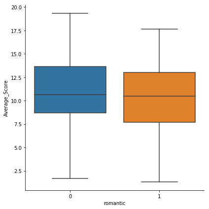

```python
sb.catplot(x="romantic", y="Average_Score",data=tidy_data, kind="box", height = 6)
```

This is the result we were expecting intuitively. We thought students not in relationships would have a higher Average Score as they would have more free time to study than their peers who would spend some of their free time with their partners.  
Now that we have analyzed all the categorical variables, let's take a look back at the original tidy_data dataset to see what numerical variables exist

```python
tidy_data.head()
```

|  | sex | age | Pstatus | studytime | failures | paid | activities | higher | internet | romantic | famrel | freetime | goout | absences | Avg_Alc_Consumption | Parent_Education | Average_Score |
| --- | --- | --- | --- | --- | --- | --- | --- | --- | --- | --- | --- | --- | --- | --- | --- | --- | --- |
| 0 | 1 | 18 | 0 | 2 | 0 | 0 | 0 | 1 | 0 | 0 | 4 | 3 | 4 | 1 | 1.0 | 4.0 | 5.666667 |
| 1 | 1 | 17 | 1 | 2 | 0 | 0 | 0 | 1 | 1 | 0 | 5 | 3 | 3 | 0 | 1.0 | 1.0 | 5.333333 |
| 2 | 1 | 15 | 1 | 2 | 3 | 1 | 0 | 1 | 1 | 0 | 4 | 3 | 2 | 1 | 2.5 | 1.0 | 8.333333 |
| 3 | 1 | 15 | 1 | 3 | 0 | 1 | 1 | 1 | 1 | 1 | 3 | 2 | 2 | 0 | 1.0 | 3.0 | 14.666667 |
| 4 | 1 | 16 | 1 | 2 | 0 | 1 | 0 | 1 | 0 | 0 | 4 | 3 | 2 | 0 | 1.5 | 3.0 | 8.666667 |

We have quite a few numerical variables. Some of them are continuous numerical variables, meaning the measured number can take on any range of values. However, some of them are discrete numerical variables meaning the number is in a fixed range of values. Dealing with variable classification for a dataset is very important as it allows you to decide the best way to analyze or visualize the particular variable. For a more in-depth explanation on types of data/variables, please see http://scaryscientist.blogspot.com/2015/02/classification-of-data-types.html.

Let's look at Average Score distributions for all our numerical variables now to see which ones we might want to include in our linear regression.

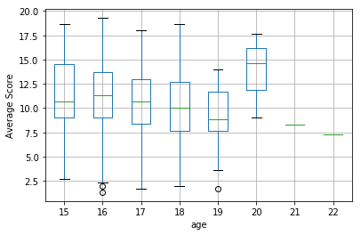

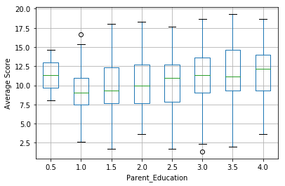

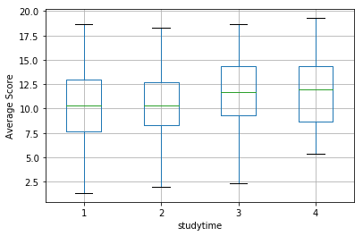

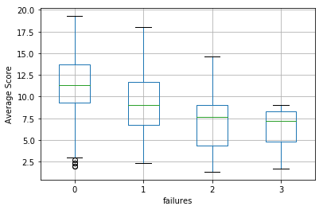

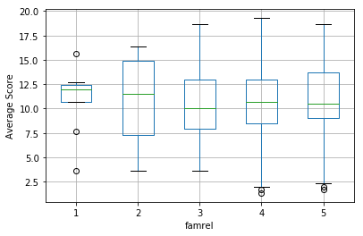

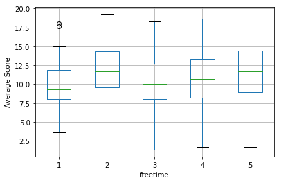

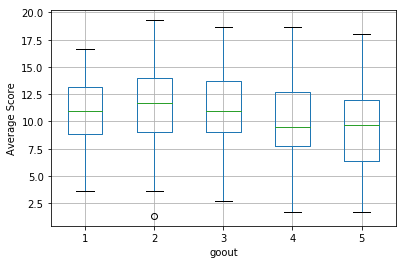

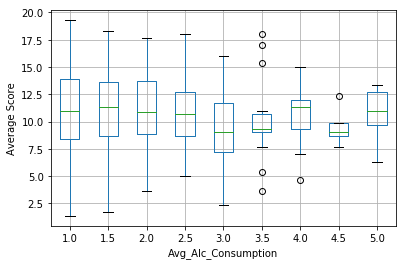

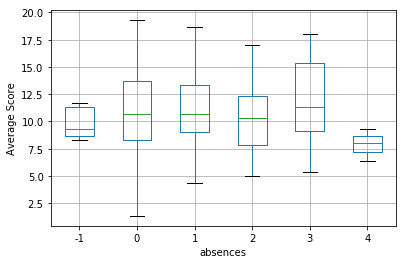

```python
tidy_data.boxplot(by='age', column='Average_Score')
plt.suptitle("")
plt.title("")
plt.ylabel("Average Score")
plt.show()
tidy_data.boxplot(by='Parent_Education', column='Average_Score')
plt.suptitle("")
plt.title("")
plt.ylabel("Average Score")
plt.show()
tidy_data.boxplot(by='studytime', column='Average_Score')
plt.suptitle("")
plt.title("")
plt.ylabel("Average Score")
plt.show()
tidy_data.boxplot(by='failures', column='Average_Score')
plt.suptitle("")
plt.title("")
plt.ylabel("Average Score")
plt.show()
tidy_data.boxplot(by='famrel', column='Average_Score')
plt.suptitle("")
plt.title("")
plt.ylabel("Average Score")
plt.show()
tidy_data.boxplot(by='freetime', column='Average_Score')
plt.suptitle("")
plt.title("")
plt.ylabel("Average Score")
plt.show()
tidy_data.boxplot(by='goout', column='Average_Score')
plt.suptitle("")
plt.title("")
plt.ylabel("Average Score")
plt.show()
tidy_data.boxplot(by='Avg_Alc_Consumption', column='Average_Score')
plt.suptitle("")
plt.title("")
plt.ylabel("Average Score")
plt.show()
tidy_data.boxplot(by='absences', column='Average_Score')
plt.suptitle("")
plt.title("")
plt.ylabel("Average Score")
plt.show()
```

- Age - distributions seem random, likely no effect on Average Score, not going to be used for linear regression
- Parent_Education - distributions increase somewhat with parent education, use for linear regression
- studytime - distributions increase somewhat with studytime, use for linear regression
- failures - distributions decrease somewhat with failures (more past failures -> lower average score), use for linear regression
- famrel - distributions seem random, likely no effect on Average Score, not going to be used for linear regression
- freetime - distributions seem random, likely no effect on Average Score, not going to be used for linear regression
- goout - distributions decrease somewhat with failures (go out less -> higher average score), use for linear regression
- Avg_Alc_Consumption - distributions don't tell us much

Let's look at a violin plot of average alcohol consumption vs average score since the boxplot didn't provide any insights.

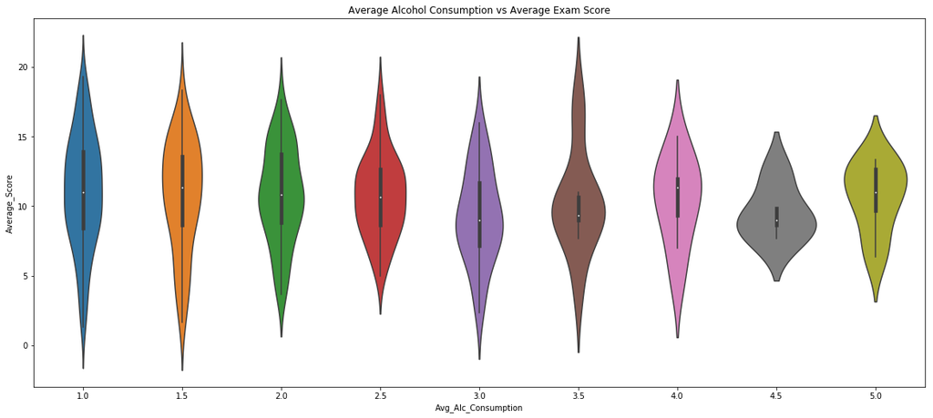

```python
fig,ax = plt.subplots()
fig.set_size_inches(20, 8.5)
plt.title("Average Alcohol Consumption vs Average Exam Score")
sb.violinplot(x=tidy_data['Avg_Alc_Consumption'],y=tidy_data['Average_Score'],ax=ax)
plt.show()
```

Violin plots are a great way to visualize distributions of data! Unfortunately, we still can't draw any conclusions from this so we will go ahead and use it in our linear regression anyways since we are interested in average alcohol consumption's effects on average score, whether it is significant or not.

So now we have our final categorical and numerical variables that we will perform linear regression on to make a predictor model for average exam score. Here is the list of the variables we will use:

#### Categorical

- Gender (binary; M or F)
- Paid (binary;pay for tutoring or not)
- Activities (binary;extracurricular activities or not)
- Higher (binary;interested in higher education or not)
- Internet (binary:internet at home or not)
- Romantic (binary:relationship or not)

Let's create a new dataframe that contains only the variables above for our linear regression.

```python
lin_df = tidy_data.drop(['age', 'Pstatus','famrel','freetime'], axis=1)
lin_df.head()
```

|  | sex | studytime | failures | paid | activities | higher | internet | romantic | goout | absences | Avg_Alc_Consumption | Parent_Education | Average_Score |
| --- | --- | --- | --- | --- | --- | --- | --- | --- | --- | --- | --- | --- | --- |
| 0 | 1 | 2 | 0 | 0 | 0 | 1 | 0 | 0 | 4 | 1 | 1.0 | 4.0 | 5.666667 |
| 1 | 1 | 2 | 0 | 0 | 0 | 1 | 1 | 0 | 3 | 0 | 1.0 | 1.0 | 5.333333 |
| 2 | 1 | 2 | 3 | 1 | 0 | 1 | 1 | 0 | 2 | 1 | 2.5 | 1.0 | 8.333333 |
| 3 | 1 | 3 | 0 | 1 | 1 | 1 | 1 | 1 | 2 | 0 | 1.0 | 3.0 | 14.666667 |
| 4 | 1 | 2 | 0 | 1 | 0 | 1 | 0 | 0 | 2 | 0 | 1.5 | 3.0 | 8.666667 |

We then looked at correlations between our new variables again.

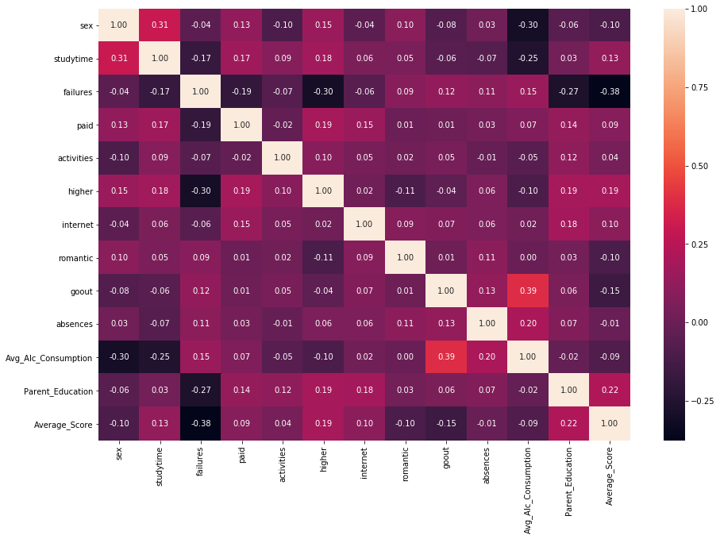

```python
plt.figure(figsize=(15,10))
sb.heatmap(lin_df.corr(), annot=True,fmt=".2f",cbar=True)
plt.show()
```

"goout" has a moderate positive correlation with Avg_Alc_Consumption which makes sense since those who go out more would tend to consume more alcohol. "studytime" also has a moderate negative correlation which also makes sense; those who study more probably have less time to go out and consume alcohol. This was important to keep in mind when we created our first multiple linear regression model becuase these two variables' correlation with Avg_Alc_Consumption could make our model worse.

```python
lm = sm.ols(formula='Average_Score~sex+studytime+failures+paid+activities+higher+internet+ \
            romantic+goout+Avg_Alc_Consumption+Parent_Education+absences', data=lin_df).fit()
lm.summary()
```

OLS Regression Results

| Dep. Variable: | Average_Score | R-squared: | 0.212 |
| --- | --- | --- | --- |
| Model: | OLS | Adj. R-squared: | 0.188 |
| Method: | Least Squares | F-statistic: | 8.578 |
| Date: | Sat, 15 Dec 2018 | Prob (F-statistic): | 1.76e-14 |
| Time: | 00:38:08 | Log-Likelihood: | -1029.3 |
| No. Observations: | 395 | AIC: | 2085. |
| Df Residuals: | 382 | BIC: | 2136. |
| Df Model: | 12 |  |  |
| Covariance Type: | nonrobust |  |  |

|  | coef | std err | t | P>\|t\| | [0.025 | 0.975] |
| --- | --- | --- | --- | --- | --- | --- |
| Intercept | 9.6602 | 1.149 | 8.410 | 0.000 | 7.402 | 11.919 |
| sex | -1.1784 | 0.379 | -3.113 | 0.002 | -1.923 | -0.434 |
| studytime | 0.4839 | 0.220 | 2.194 | 0.029 | 0.050 | 0.917 |
| failures | -1.4368 | 0.252 | -5.694 | 0.000 | -1.933 | -0.941 |
| paid | -0.0014 | 0.359 | -0.004 | 0.997 | -0.708 | 0.705 |
| activities | -0.1612 | 0.345 | -0.467 | 0.641 | -0.840 | 0.517 |
| higher | 1.1660 | 0.839 | 1.391 | 0.165 | -0.483 | 2.815 |
| internet | 0.6205 | 0.466 | 1.332 | 0.184 | -0.296 | 1.537 |
| romantic | -0.5546 | 0.366 | -1.515 | 0.131 | -1.274 | 0.165 |
| goout | -0.4316 | 0.166 | -2.593 | 0.010 | -0.759 | -0.104 |
| Avg_Alc_Consumption | -0.0657 | 0.202 | -0.325 | 0.746 | -0.463 | 0.332 |
| Parent_Education | 0.4316 | 0.185 | 2.335 | 0.020 | 0.068 | 0.795 |
| absences | 0.2018 | 0.205 | 0.982 | 0.327 | -0.202 | 0.606 |

| Omnibus: | 3.492 | Durbin-Watson: | 2.101 |
| --- | --- | --- | --- |
| Prob(Omnibus): | 0.174 | Jarque-Bera (JB): | 3.133 |
| Skew: | -0.143 | Prob(JB): | 0.209 |
| Kurtosis: | 2.671 | Cond. No. | 42.0 |

Warnings:  
[1] Standard Errors assume that the covariance matrix of the errors is correctly specified.

The R-squared value for our first model is 0.212. This means that 21.2% of the variability in our dependent variable Average_Score can be explained by our independent variables. R-squared values range from 0 to 1 and ideally we want it to be as close to 1 as possible. Our adjusted R-squared value is 0.188. Adjusted R-squared modifies the R-squared value to take into account the number of predictors(independent variables) because R-squared always goes up as you add more predictors. So we will focus on the adjusted R-squared value. See http://blog.minitab.com/blog/adventures-in-statistics-2/multiple-regession-analysis-use-adjusted-r-squared-and-predicted-r-squared-to-include-the-correct-number-of-variables for a better explanation and information about analyzing multiple regression models  
We then look at the p-values for each independent variable. This tells us how significant the variable is to the model. Paid, activities, and Avg_Alc_Consumption all have large p-values. However, this may be because there are other variables with lower p-values that are already contributing to the model and making these three variables insignificant. Let's make another model taking the paid variable out since it has the largest p-value.

```python
lm1 = sm.ols(formula='Average_Score~sex+studytime+failures+activities+higher+internet+ \
            romantic+goout+Avg_Alc_Consumption+Parent_Education+absences', data=lin_df).fit()
lm1.summary()
```

OLS Regression Results

| Dep. Variable: | Average_Score | R-squared: | 0.212 |
| --- | --- | --- | --- |
| Model: | OLS | Adj. R-squared: | 0.190 |
| Method: | Least Squares | F-statistic: | 9.382 |
| Date: | Sat, 15 Dec 2018 | Prob (F-statistic): | 5.56e-15 |
| Time: | 00:38:45 | Log-Likelihood: | -1029.3 |
| No. Observations: | 395 | AIC: | 2083. |
| Df Residuals: | 383 | BIC: | 2130. |
| Df Model: | 11 |  |  |
| Covariance Type: | nonrobust |  |  |

|  | coef | std err | t | P>\|t\| | [0.025 | 0.975] |
| --- | --- | --- | --- | --- | --- | --- |
| Intercept | 9.6606 | 1.142 | 8.462 | 0.000 | 7.416 | 11.905 |
| sex | -1.1786 | 0.375 | -3.139 | 0.002 | -1.917 | -0.440 |
| studytime | 0.4838 | 0.219 | 2.213 | 0.028 | 0.054 | 0.914 |
| failures | -1.4367 | 0.250 | -5.742 | 0.000 | -1.929 | -0.945 |
| activities | -0.1612 | 0.344 | -0.468 | 0.640 | -0.838 | 0.516 |
| higher | 1.1656 | 0.832 | 1.401 | 0.162 | -0.471 | 2.802 |
| internet | 0.6203 | 0.461 | 1.345 | 0.179 | -0.287 | 1.527 |
| romantic | -0.5546 | 0.366 | -1.517 | 0.130 | -1.273 | 0.164 |
| goout | -0.4315 | 0.166 | -2.597 | 0.010 | -0.758 | -0.105 |
| Avg_Alc_Consumption | -0.0658 | 0.200 | -0.330 | 0.742 | -0.458 | 0.327 |
| Parent_Education | 0.4315 | 0.184 | 2.344 | 0.020 | 0.070 | 0.793 |
| absences | 0.2018 | 0.205 | 0.983 | 0.326 | -0.202 | 0.605 |

| Omnibus: | 3.492 | Durbin-Watson: | 2.101 |
| --- | --- | --- | --- |
| Prob(Omnibus): | 0.174 | Jarque-Bera (JB): | 3.133 |
| Skew: | -0.143 | Prob(JB): | 0.209 |
| Kurtosis: | 2.671 | Cond. No. | 41.6 |

Warnings:  
[1] Standard Errors assume that the covariance matrix of the errors is correctly specified.

After taking out the paid variable, our adjusted R-squared went up very slightly to 0.190. Activities and Avg_Alc_Consumption still have very high p-values. Let's take out activities now.

```python
lm2 = sm.ols(formula='Average_Score~sex+studytime+failures+higher+internet+ \
            romantic+goout+Avg_Alc_Consumption+Parent_Education+absences', data=lin_df).fit()
lm2.summary()
```

OLS Regression Results

| Dep. Variable: | Average_Score | R-squared: | 0.212 |
| --- | --- | --- | --- |
| Model: | OLS | Adj. R-squared: | 0.191 |
| Method: | Least Squares | F-statistic: | 10.32 |
| Date: | Sat, 15 Dec 2018 | Prob (F-statistic): | 1.85e-15 |
| Time: | 00:39:04 | Log-Likelihood: | -1029.4 |
| No. Observations: | 395 | AIC: | 2081. |
| Df Residuals: | 384 | BIC: | 2125. |
| Df Model: | 10 |  |  |
| Covariance Type: | nonrobust |  |  |

|  | coef | std err | t | P>\|t\| | [0.025 | 0.975] |
| --- | --- | --- | --- | --- | --- | --- |
| Intercept | 9.6370 | 1.139 | 8.458 | 0.000 | 7.397 | 11.877 |
| sex | -1.1521 | 0.371 | -3.107 | 0.002 | -1.881 | -0.423 |
| studytime | 0.4743 | 0.217 | 2.181 | 0.030 | 0.047 | 0.902 |
| failures | -1.4357 | 0.250 | -5.744 | 0.000 | -1.927 | -0.944 |
| higher | 1.1350 | 0.829 | 1.369 | 0.172 | -0.495 | 2.764 |
| internet | 0.6177 | 0.461 | 1.341 | 0.181 | -0.288 | 1.523 |
| romantic | -0.5609 | 0.365 | -1.537 | 0.125 | -1.279 | 0.157 |
| goout | -0.4371 | 0.166 | -2.640 | 0.009 | -0.763 | -0.112 |
| Avg_Alc_Consumption | -0.0579 | 0.199 | -0.292 | 0.771 | -0.449 | 0.333 |
| Parent_Education | 0.4248 | 0.183 | 2.317 | 0.021 | 0.064 | 0.785 |
| absences | 0.2024 | 0.205 | 0.987 | 0.324 | -0.201 | 0.605 |

| Omnibus: | 3.505 | Durbin-Watson: | 2.100 |
| --- | --- | --- | --- |
| Prob(Omnibus): | 0.173 | Jarque-Bera (JB): | 3.109 |
| Skew: | -0.138 | Prob(JB): | 0.211 |
| Kurtosis: | 2.665 | Cond. No. | 41.4 |

Warnings:  
[1] Standard Errors assume that the covariance matrix of the errors is correctly specified.

After taking out the activities variable, our adjusted R-squared went up very slightly again to 0.191. Avg_Alc_Consumption is the only variable left with a very high p-value. Let's make one last model taking this out.

```python
lm3 = sm.ols(formula='Average_Score~sex+studytime+failures+higher+internet+ \
            romantic+goout+Parent_Education+absences', data=lin_df).fit()
lm3.summary()
```

OLS Regression Results

| Dep. Variable: | Average_Score | R-squared: | 0.212 |
| --- | --- | --- | --- |
| Model: | OLS | Adj. R-squared: | 0.193 |
| Method: | Least Squares | F-statistic: | 11.48 |
| Date: | Sat, 15 Dec 2018 | Prob (F-statistic): | 5.45e-16 |
| Time: | 00:42:00 | Log-Likelihood: | -1029.5 |
| No. Observations: | 395 | AIC: | 2079. |
| Df Residuals: | 385 | BIC: | 2119. |
| Df Model: | 9 |  |  |
| Covariance Type: | nonrobust |  |  |

|  | coef | std err | t | P>\|t\| | [0.025 | 0.975] |
| --- | --- | --- | --- | --- | --- | --- |
| Intercept | 9.5465 | 1.095 | 8.719 | 0.000 | 7.394 | 11.699 |
| sex | -1.1252 | 0.359 | -3.137 | 0.002 | -1.830 | -0.420 |
| studytime | 0.4838 | 0.215 | 2.253 | 0.025 | 0.062 | 0.906 |
| failures | -1.4391 | 0.249 | -5.771 | 0.000 | -1.929 | -0.949 |
| higher | 1.1376 | 0.828 | 1.374 | 0.170 | -0.490 | 2.765 |
| internet | 0.6182 | 0.460 | 1.343 | 0.180 | -0.287 | 1.523 |
| romantic | -0.5620 | 0.365 | -1.542 | 0.124 | -1.279 | 0.155 |
| goout | -0.4548 | 0.154 | -2.957 | 0.003 | -0.757 | -0.152 |
| Parent_Education | 0.4274 | 0.183 | 2.336 | 0.020 | 0.068 | 0.787 |
| absences | 0.1923 | 0.202 | 0.953 | 0.341 | -0.205 | 0.589 |

| Omnibus: | 3.498 | Durbin-Watson: | 2.100 |
| --- | --- | --- | --- |
| Prob(Omnibus): | 0.174 | Jarque-Bera (JB): | 3.053 |
| Skew: | -0.130 | Prob(JB): | 0.217 |
| Kurtosis: | 2.657 | Cond. No. | 37.8 |

Warnings:  
[1] Standard Errors assume that the covariance matrix of the errors is correctly specified.

```python
lin_df.head()
```

|  | sex | studytime | failures | paid | activities | higher | internet | romantic | goout | absences | Avg_Alc_Consumption | Parent_Education | Average_Score |
| --- | --- | --- | --- | --- | --- | --- | --- | --- | --- | --- | --- | --- | --- |
| 0 | 1 | 2 | 0 | 0 | 0 | 1 | 0 | 0 | 4 | 1 | 1.0 | 4.0 | 5.666667 |
| 1 | 1 | 2 | 0 | 0 | 0 | 1 | 1 | 0 | 3 | 0 | 1.0 | 1.0 | 5.333333 |
| 2 | 1 | 2 | 3 | 1 | 0 | 1 | 1 | 0 | 2 | 1 | 2.5 | 1.0 | 8.333333 |
| 3 | 1 | 3 | 0 | 1 | 1 | 1 | 1 | 1 | 2 | 0 | 1.0 | 3.0 | 14.666667 |
| 4 | 1 | 2 | 0 | 1 | 0 | 1 | 0 | 0 | 2 | 0 | 1.5 | 3.0 | 8.666667 |

First let's take out the variables we dropped from our linear regression model.

```python
df=lin_df.copy()
df = df.drop(['paid', 'activities', 'Avg_Alc_Consumption'], axis=1)
for i in df.iterrows():
    df['Predicted_Score'] = lm3.predict(df)

df['Residuals'] = df['Average_Score'] - df['Predicted_Score']
df.head()
```

|  | sex | studytime | failures | higher | internet | romantic | goout | absences | Parent_Education | Average_Score | Predicted_Score | Residuals |
| --- | --- | --- | --- | --- | --- | --- | --- | --- | --- | --- | --- | --- |
| 0 | 1 | 2 | 0 | 1 | 0 | 0 | 4 | 1 | 4.0 | 5.666667 | 10.608816 | -4.942149 |
| 1 | 1 | 2 | 0 | 1 | 1 | 0 | 3 | 0 | 1.0 | 5.333333 | 10.207448 | -4.874114 |
| 2 | 1 | 2 | 3 | 1 | 1 | 0 | 2 | 1 | 1.0 | 8.333333 | 6.537218 | 1.796115 |
| 3 | 1 | 3 | 0 | 1 | 1 | 1 | 2 | 0 | 3.0 | 14.666667 | 11.438843 | 3.227824 |
| 4 | 1 | 2 | 0 | 1 | 0 | 0 | 2 | 0 | 3.0 | 8.666667 | 10.898874 | -2.232207 |

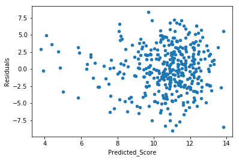

```python
df.plot(y='Residuals', x='Predicted_Score', kind='scatter')
```

## Conclusions

The objective of our project was to investigate factors that may affect student exam performance. After going through the entire data analysis, we came to the conclusion that there is no one factor that best predicts exam performance. We started by looking at the correlations between the variables and student's exam scores. However, there were no strong correlations for any of the variables so we then conducted hypothesis tests for the variables to see if there was any significant effect on exam scores. We then applied machine learning by creating multiple linear regression models and then refining the model based on the p-values for each variable.  
If we were to conduct further analysis, we could find other similar datasets and apply what we did here to see if any variables would be more substantial in predicting exam performance. We could also do more in-depth testing on each of the variables in relation to exam scores to try creating a better model.